# EUR LD panel held-out imputation comparison

UKB EUR versus matched HGDP+1kGP EUR on five UKB-B regions

## Question and result

This experiment asks a narrow practical question: if known UKB-B associations are hidden, how accurately does reference completion recover their beta values using the production UKB EUR panel versus the newly generated HGDP+1kGP EUR panel?

The primary estimand is the **within-analysis Pearson correlation between known and imputed betas**, conditional on at least three held-out observations. Acceptance rate is reported separately and is equally important: an LD panel should not look better merely because the quality gate rejects difficult analyses.

Held-out beta recovery across five regions.

| panel | eligible.analysis.regions | accepted.pct | median.Pearson.r | Q1.Pearson.r | Q3.Pearson.r | median.Spearman.r | median.RMSE | median.slope |
| --- | --- | --- | --- | --- | --- | --- | --- | --- |
| UKB EUR | 12570 | 99.912 | 0.978 | 0.966 | 0.986 | 0.975 | 8.49e-05 | 0.957 |
| HGDP+1kGP EUR | 12570 | 98.886 | 0.963 | 0.940 | 0.978 | 0.962 | 1.15e-04 | 0.933 |

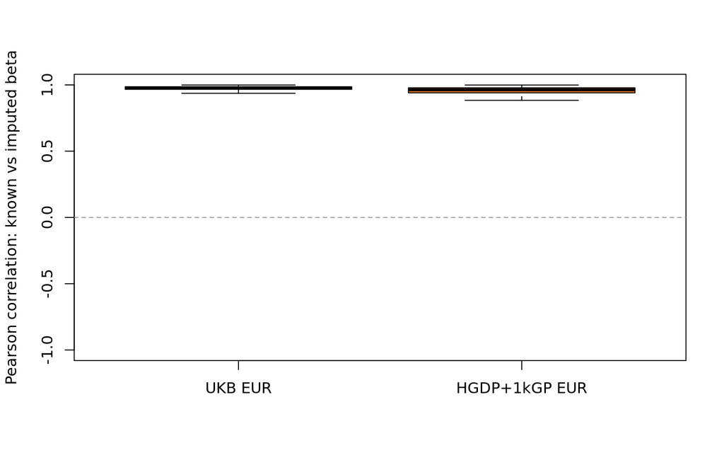

Distribution of within-analysis held-out beta correlations. Only accepted analysis-region fits with at least three known held-out betas are shown; acceptance is tabulated separately above.

## Design

- Source truth is `/data/opengwasdb/wip/ukb-b-c128.opengwasdb`, the observed-only store with 2,514 analyses. A beta is reconstructed as `z × se`.
- `/data/opengwasdb/wip/ukb-b-c128-completed.opengwasdb` establishes the production completion parameters and expected store lineage, but is **not** used as truth for originally missing cells: those values were already imputed.
- Five matched UKB block boundaries were selected across chromosomes 1, 6, 11, 16, and 22. These are not hand-picked by outcome accuracy.
- Candidate targets must occur in the observed store and both LD panels. Within each region, 20% of these variants are selected once using seed `20260806` and hidden identically from both panels for every analysis.
- All other observed variants represented by a panel remain available for training. Thus target truth is paired, while each panel retains its real-world variant coverage.
- The production kernel is used: eigenvectors truncated at 90% cumulative variance, elastic-net regression, polynomial rescaling, minimum training correlation 0.7, and the ±1 Mb observed-z cap. Standard errors use the panel’s allele frequency and the scalar-N model.

### Data-integrity correction

The first execution of this experiment was deliberately withheld from reporting: it exposed an allele-orientation defect in the new panel constructor. PLINK’s ALT dosages had been decomposed while the output table declared the lexicographically canonical effect allele, reversing the required LD sign whenever canonical EA was REF. A signed-LD regression test now locks down this invariant, the constructor orients centred dosages before SVD, and all generated ancestry panels were rebuilt. The results here are from the corrected artifacts. This is also why held-out validation is a release gate rather than only a descriptive benchmark.

Shared candidate and masked variant counts.

| region | n_shared_variants | n_masked_variants |
| --- | --- | --- |
| chr1:222798680-224041489 | 2346 | 469 |
| chr11:30827313-33937829 | 5589 | 1118 |
| chr16:60049115-62536937 | 4831 | 966 |
| chr22:32439511-33959775 | 3970 | 794 |
| chr6:30106780-30425675 | 1503 | 301 |

## Region-level results

Accuracy and acceptance by region.

| region | panel | eligible | accepted.pct | median.Pearson.r | median.RMSE |
| --- | --- | --- | --- | --- | --- |
| chr1:222798680-224041489 | HGDP+1kGP EUR | 2514 | 99.761 | 0.971 | 1.00e-04 |
| chr1:222798680-224041489 | UKB EUR | 2514 | 99.960 | 0.977 | 8.70e-05 |
| chr11:30827313-33937829 | HGDP+1kGP EUR | 2514 | 99.483 | 0.959 | 1.21e-04 |
| chr11:30827313-33937829 | UKB EUR | 2514 | 99.920 | 0.979 | 8.31e-05 |
| chr16:60049115-62536937 | HGDP+1kGP EUR | 2514 | 99.761 | 0.964 | 1.09e-04 |
| chr16:60049115-62536937 | UKB EUR | 2514 | 100.000 | 0.983 | 7.27e-05 |
| chr22:32439511-33959775 | HGDP+1kGP EUR | 2514 | 95.426 | 0.931 | 1.42e-04 |
| chr22:32439511-33959775 | UKB EUR | 2514 | 99.682 | 0.967 | 9.95e-05 |
| chr6:30106780-30425675 | HGDP+1kGP EUR | 2514 | 100.000 | 0.975 | 1.07e-04 |
| chr6:30106780-30425675 | UKB EUR | 2514 | 100.000 | 0.984 | 7.75e-05 |

## Paired panel difference

The most direct comparison retains only analysis-region pairs successfully imputed by both panels and subtracts the HGDP+1kGP correlation from the UKB correlation. This conditional contrast is accompanied by the unconditional acceptance rates above.

Paired difference in held-out beta correlation.

| paired.analysis.regions | median.UKB.minus.HGDP | mean.UKB.minus.HGDP | UKB.higher.pct | equal.pct |
| --- | --- | --- | --- | --- |
| 12421 | 0.014 | 0.019 | 91.216 | 0 |

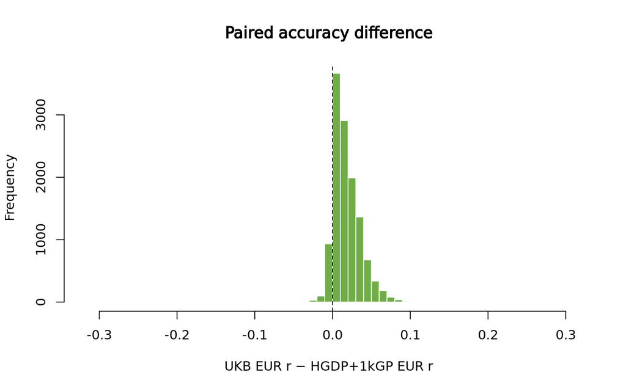

Paired difference in Pearson correlation; positive values favour UKB EUR.

## Interpretation and limits

This is a calibration experiment, not a genome-wide equivalence claim. It covers five blocks and UKB-B traits, whose participants are predominantly European and therefore favour ancestry matching to the UKB panel. Correlations are unstable when very few held-out betas are available, which is why fewer than three are excluded. The fixed global mask tests variant recovery but does not reproduce every possible missingness pattern. A release decision should add more blocks, repeated masks, allele-frequency strata, and traits from non-UKB cohorts.